# EconomicData__FinalProject_Corredor

Understanding GDP Growth Through Data

Author: Leonardo Corredor

Economic growth is an important indicator of how an economy is performing over time. Many economic and financial variables are often mentioned as possible drivers of GDP growth, but it is not always clear which of them actually show a meaningful relationship with it. Furthermore historical, political and natural milestones can crack nations and world economies.

The main question of this project is: Which macroeconomic and financial variables are related to GDP growth, and can these variables be used to predict future GDP growth?

To explore this question, this project uses a dataset with annual economic data from nine countries covering several decades. GDP growth, measured as the annual percentage change in GDP, is used as the target variable. This data set has the information of:

-Stock Index

-Country

-Year

-Price in the NASDAQ index: The numerical value of a stock index at a specific point in time, representing the general price level of its component stocks.

-Log_IndexPrice:The natural logarithm of the index price. This mathematical transformation is often used in statistical or econometric analysis to stabilize variance and simplify modeling.

-Inflation Rate: The percentage change in the general price level of goods and services over a certain period. It indicates the rate at which purchasing power is declining.

-Oil Prices: The market price of a barrel of crude oil (Valid just for the USA)

-Exchange Rate: The value of one currency expressed in terms of another. For example, how many pesos are needed to buy one U.S. dollar.

-GDP Percent (GDP Growth Rate): The percentage change in a country’s Gross Domestic Product (GDP)

-Per Capita Income: The average income earned per person in a given country. Calculated by dividing total GDP by the population.

-Unemployment Rate: The percentage of the labor force that is unemployed.

-Manufacturing Output: The total value or quantity of goods produced by the manufacturing sector. It measures industrial production activity.

-Trade Balance: The difference between the value of a country’s exports and imports.(Positive → trade surplus // Negative → trade deficit)

-U.S. Treasury: Refers to U.S. government securities (such as Treasury bonds, notes, and bills) issued to finance national debt.

The analysis follows a simple and structured approach. First, introductory visualizations. Then a statistical screening is used to check which variables are actually correlated with GDP growth. Third, only the selected variables are analyzed further using visual exploration, statistical tests, and regression models. Finally, a small machine learning model is trained to evaluate how well these variables can predict GDP growth in a realistic, time-based setting.

In this report, the reader will find a description of the data, the variable selection process, exploratory visualizations, inferential analysis, and both explanatory and predictive models, followed by a discussion of the results and their limitations.

```python
## 1. Environment Setup
import pandas as pd
import numpy as np
import matplotlib.pyplot as plt
import seaborn as sns
import plotly.express as px
import plotly.graph_objects as go
from plotly.subplots import make_subplots
import warnings
warnings.filterwarnings('ignore')
```

```python
from sklearn.model_selection import train_test_split
from sklearn.ensemble import RandomForestRegressor
from sklearn.metrics import mean_squared_error, mean_absolute_error
```

```python
from sklearn.preprocessing import StandardScaler
from sklearn.preprocessing import LabelEncoder

from sklearn.tree import DecisionTreeClassifier
from sklearn.ensemble import RandomForestClassifier
from sklearn.naive_bayes import GaussianNB
from sklearn.neighbors import KNeighborsClassifier
from sklearn.svm import SVC
from sklearn.neural_network import MLPClassifier
from sklearn.ensemble import AdaBoostClassifier
from sklearn.ensemble import GradientBoostingClassifier
from sklearn.ensemble import ExtraTreesClassifier
from sklearn.linear_model import LogisticRegression
from sklearn.model_selection import train_test_split
from sklearn.metrics import accuracy_score
```

Data Loading and Exploratory Analisys

```python
from pathlib import Path
import pandas as pd

DATA_PATH = Path("dataset")/"Economic_Data _9_Countries_1980_2020.csv"
df = pd.read_csv(DATA_PATH)

df.head()
```

|  | stock index | country | year | index price | log_indexprice | inflationrate | oil prices | exchange_rate | gdppercent | percapitaincome | unemploymentrate | manufacturingoutput | tradebalance | USTreasury |
| --- | --- | --- | --- | --- | --- | --- | --- | --- | --- | --- | --- | --- | --- | --- |
| 0 | NASDAQ | United States of America | 1980.0 | 168.61 | 2.23 | 0.14 | 21.59 | 1.0 | 0.09 | 12575.0 | 0.07 | NaN | -13.06 | 0.11 |
| 1 | NASDAQ | United States of America | 1981.0 | 203.15 | 2.31 | 0.10 | 31.77 | 1.0 | 0.12 | 13976.0 | 0.08 | NaN | -12.52 | 0.14 |
| 2 | NASDAQ | United States of America | 1982.0 | 188.98 | 2.28 | 0.06 | 28.52 | 1.0 | 0.04 | 14434.0 | 0.10 | NaN | -19.97 | 0.13 |
| 3 | NASDAQ | United States of America | 1983.0 | 285.43 | 2.46 | 0.03 | 26.19 | 1.0 | 0.09 | 15544.0 | 0.10 | NaN | -51.64 | 0.11 |
| 4 | NASDAQ | United States of America | 1984.0 | 248.89 | 2.40 | 0.04 | 25.88 | 1.0 | 0.11 | 17121.0 | 0.08 | NaN | -102.73 | 0.12 |

```python
df.info()
```

```
<class 'pandas.core.frame.DataFrame'>
RangeIndex: 369 entries, 0 to 368
Data columns (total 14 columns):
 #   Column               Non-Null Count  Dtype
---  ------               --------------  -----
 0   stock index          369 non-null    object
 1   country              369 non-null    object
 2   year                 369 non-null    float64
 3   index price          317 non-null    float64
 4   log_indexprice       369 non-null    float64
 5   inflationrate        326 non-null    float64
 6   oil prices           369 non-null    float64
 7   exchange_rate        367 non-null    float64
 8   gdppercent           350 non-null    float64
 9   percapitaincome      368 non-null    float64
 10  unemploymentrate     348 non-null    float64
 11  manufacturingoutput  278 non-null    float64
 12  tradebalance         365 non-null    float64
 13  USTreasury           369 non-null    float64
dtypes: float64(12), object(2)
memory usage: 40.5+ KB
```

Lets proceed with some introductory visualizations to target possible relationships between variables.

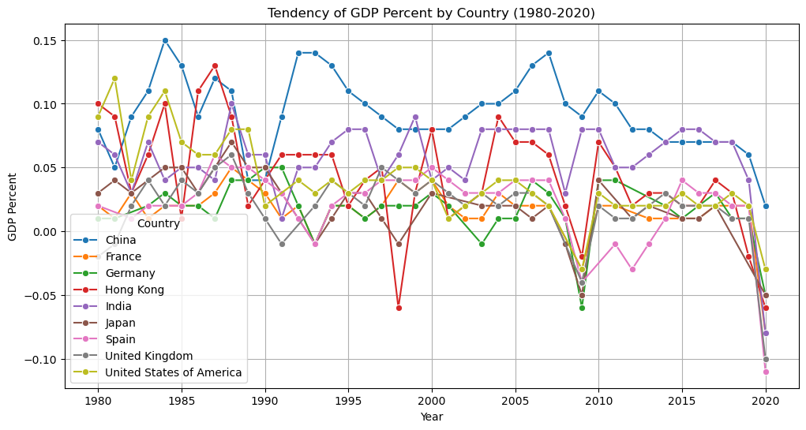

```python
#Group by Country and Year to analyse the GDP Percent over the years
cols_to_use4 = ['country', 'year', 'gdppercent']
df_gdp = df[cols_to_use4].copy()
df_gdp = df[cols_to_use4].groupby(['country', 'year'], as_index=False).mean()

# Visualization of the GDP Percent over the Years
plt.figure(figsize=(12, 6))
sns.lineplot(data= df_gdp, x="year", y="gdppercent", hue="country", marker="o")

plt.title("Tendency of GDP Percent by Country (1980-2020)")
plt.xlabel("Year")
plt.ylabel("GDP Percent")
plt.legend(title="Country")
plt.grid(True)
plt.show()
```

-Economic growth trends in Western countries remain similar.

-The economic growth of China, India and Hong Kong reflects the economic boom in Asia in recent decades.

-The transfer of sovereignty over Hong Kong from the United Kingdom to China in 1997 is evident in economic resentment, but once the transition was over, Hong Kong's economy returned to its growth trend.

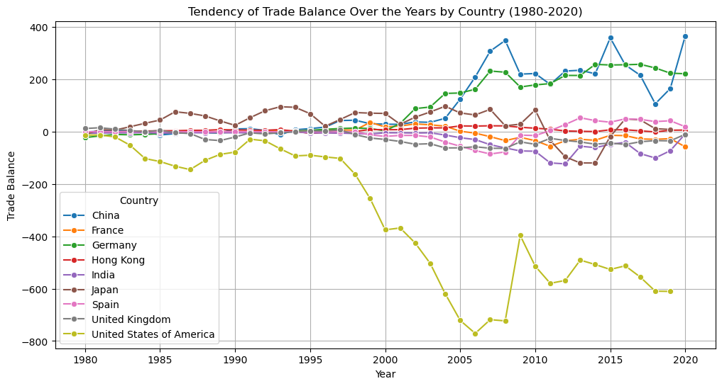

```python
#Group by Country and Year to analyse the tendency of Trade Balance over the years
cols_to_use2 = ['country', 'year', 'tradebalance']
df_tradebalance = df[cols_to_use2].copy()
df_tradebalance = df[cols_to_use2].groupby(['country', 'year'], as_index=False).mean()

# Visualization of the Trade Balance over the Years
plt.figure(figsize=(12, 6))
sns.lineplot(data=df_tradebalance, x="year", y="tradebalance", hue="country", marker="o")

plt.title("Tendency of Trade Balance Over the Years by Country (1980-2020)")
plt.xlabel("Year")
plt.ylabel("Trade Balance")
plt.legend(title="Country")
plt.grid(True)
plt.show()
```

-Trade Balance rates remain volatile, although less abruptly than in the previous index for most countries.

-China shows striking growth in its Trade Balance compared to other countries, demonstrating that its industrial production does not remain within the country but is sent internationally.

-Germany leads the Trade Balance index among European countries.

-Imports to the United States have grown dramatically since the 1990s.

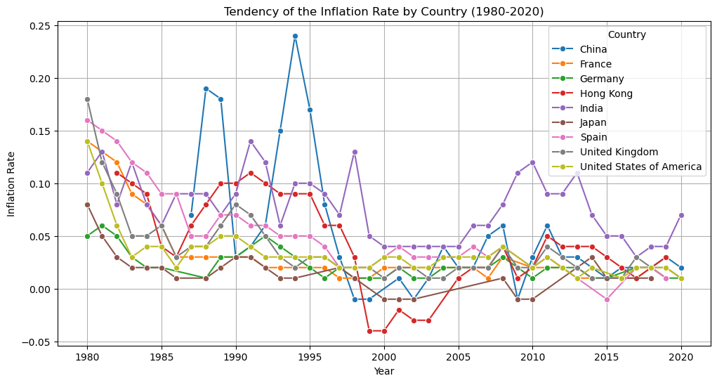

```python
#Group by Country and Year to analyse the Inflation Rate output over the years
cols_to_use7 = ['country', 'year', 'inflationrate']
df_infl = df[cols_to_use7].copy()
df_infl = df[cols_to_use7].groupby(['country', 'year'], as_index=False).mean()

# Visualization of the Inflation Rate over the Years
plt.figure(figsize=(12, 6))
sns.lineplot(data= df_infl, x="year", y="inflationrate", hue="country", marker="o")

plt.title("Tendency of the Inflation Rate by Country (1980-2020)")
plt.xlabel("Year")
plt.ylabel("Inflation Rate")
plt.legend(title="Country")
plt.grid(True)
plt.show()
```

-The trend in Western countries remains stable, as in other indices, with less abrupt ups and downs.

-In the case of Asian powers, inflation rises before and during economic booms. However, although growth remains constant over the years, inflation is regulated.

-The transfer of sovereignty over Hong Kong from the United Kingdom to China in 1997 is evident in economic resentment making decrease the inflation rate as well, but once the transition was over, Hong Kong's economy returned to its growth trend causing the growuth of the inflation rate.

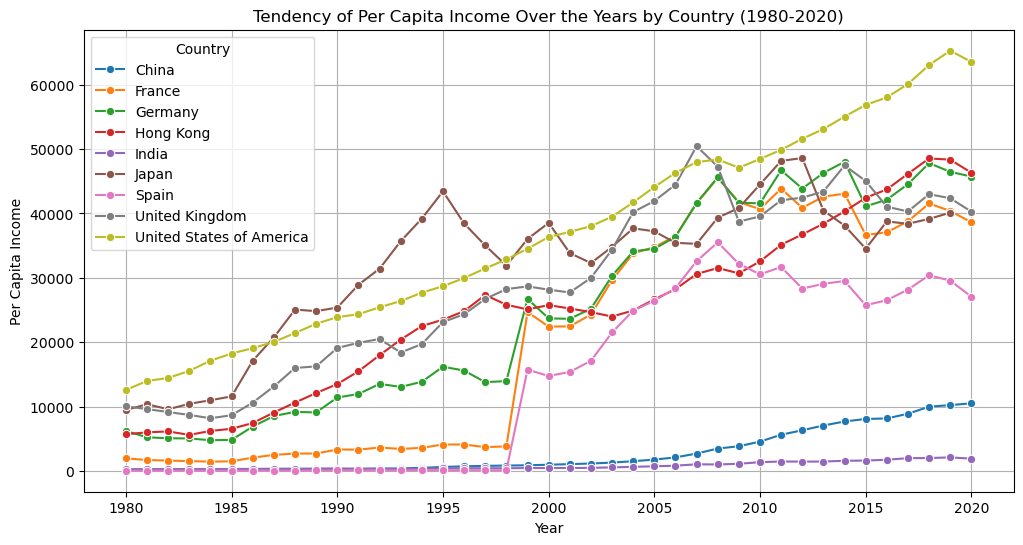

```python
#Group by Country and Year to analyse the tendency of Income Per Capita  over the years
cols_to_use1 = ['country', 'year', 'percapitaincome']
df_percapitaincome = df[cols_to_use1].copy()
df_percapitaincome = df[cols_to_use1].groupby(['country', 'year'], as_index=False).mean()

# Visualization of Income Per Capita Growing
plt.figure(figsize=(12, 6))
sns.lineplot(data=df_percapitaincome, x="year", y="percapitaincome", hue="country", marker="o")

plt.title("Tendency of Per Capita Income Over the Years by Country (1980-2020)")
plt.xlabel("Year")
plt.ylabel("Per Capita Income")
plt.legend(title="Country")
plt.grid(True)
plt.show()
```

-Despite the economic boom in India and China, their per capita income is not growing proportionally. It is worth investigating the social and political causes behind this trend.

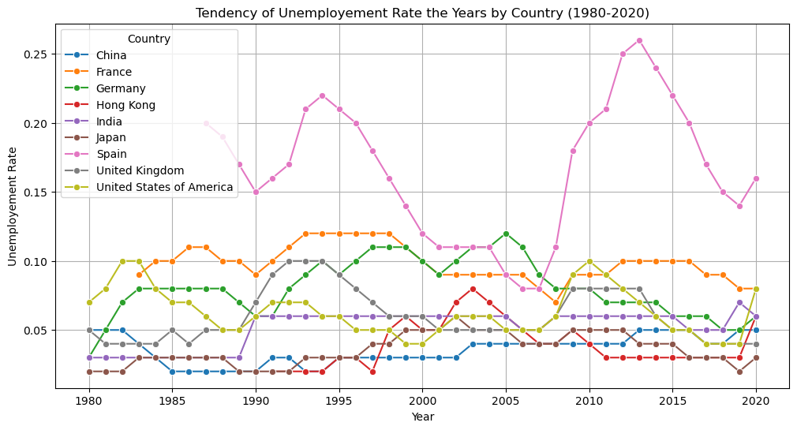

```python
#Group by Country and Year to analyse the unemployement rate over the years
cols_to_use3 = ['country', 'year', 'unemploymentrate']
df_unemployement = df[cols_to_use3].copy()
df_unemployement = df[cols_to_use3].groupby(['country', 'year'], as_index=False).mean()

# Visualization of the unemployement rate over the Years
plt.figure(figsize=(12, 6))
sns.lineplot(data= df_unemployement, x="year", y="unemploymentrate", hue="country", marker="o")

plt.title("Tendency of Unemployement Rate the Years by Country (1980-2020)")
plt.xlabel("Year")
plt.ylabel("Unemployement Rate")
plt.legend(title="Country")
plt.grid(True)
plt.show()
```

-Most unemployment trends in Western countries remain similar, except for the atypical case of Spain, where they are dramatically higher.

-The widespread economic resentment in Hong Kong in 1997 continues to be evident.

DATA PROCESSING FOR MODELING Slitting into train and tests sets

```python
#Group by Country and Year to analyse the tendency of GPD over the years
#I use the function lag to take the previous year GDP to predict the current year GDP
df1 = df.copy()
df1 ['gdppercent_Lag1'] = df.groupby('country',)['gdppercent'].shift(1)
df1. head()
```

|  | stock index | country | year | index price | log_indexprice | inflationrate | oil prices | exchange_rate | gdppercent | percapitaincome | unemploymentrate | manufacturingoutput | tradebalance | USTreasury | gdppercent_Lag1 |
| --- | --- | --- | --- | --- | --- | --- | --- | --- | --- | --- | --- | --- | --- | --- | --- |
| 0 | NASDAQ | United States of America | 1980.0 | 168.61 | 2.23 | 0.14 | 21.59 | 1.0 | 0.09 | 12575.0 | 0.07 | NaN | -13.06 | 0.11 | NaN |
| 1 | NASDAQ | United States of America | 1981.0 | 203.15 | 2.31 | 0.10 | 31.77 | 1.0 | 0.12 | 13976.0 | 0.08 | NaN | -12.52 | 0.14 | 0.09 |
| 2 | NASDAQ | United States of America | 1982.0 | 188.98 | 2.28 | 0.06 | 28.52 | 1.0 | 0.04 | 14434.0 | 0.10 | NaN | -19.97 | 0.13 | 0.12 |
| 3 | NASDAQ | United States of America | 1983.0 | 285.43 | 2.46 | 0.03 | 26.19 | 1.0 | 0.09 | 15544.0 | 0.10 | NaN | -51.64 | 0.11 | 0.04 |
| 4 | NASDAQ | United States of America | 1984.0 | 248.89 | 2.40 | 0.04 | 25.88 | 1.0 | 0.11 | 17121.0 | 0.08 | NaN | -102.73 | 0.12 | 0.09 |

To include temporal information in the analysis a one-year lag of GDP growth is created for each country. This variable represents GDP growth in the previous year and captures short-term persistence in economic performance.

The lag is computed within each country to respect the panel structure of the data. As expected, the first observation for each country has a missing value for the lagged variable. This feature is later used in the modeling part to improve predictions.

Now we begin to work the data for a Machine Learning Model to predict the GDP Percent based on other economic indicators.First we define the values for ALPHA, FDR_Method and MIN_ABS_CORR for the further statistical tests we will use to define wich variables come to be important for our project.

```python
#Dfining the constants for statistical analysis.

ALPHA = 0.05  #It defines the significance level for statistical tests.
FDR_METHOD = "fdr_bh"  # It dfines the correction method for multiple hypothesis testing (False Discovery Rate).
MIN_ABS_CORR = 0.10  # It defines the minimum rate of correlation to consider a variable relevant.


print("ALPHA for statistical analysis:", ALPHA)
print("FDR_METHOD for multiple hypothesis testing:", FDR_METHOD)
print("MIN_ABS_CORR for relevant variable selection:", MIN_ABS_CORR)
```

```
ALPHA for statistical analysis: 0.05
FDR_METHOD for multiple hypothesis testing: fdr_bh
MIN_ABS_CORR for relevant variable selection: 0.1
```

```python
#Dfining the relevant columns for the analysis.

country_col = "country"
year_col = "year" #It defines the year column being type float but it will be converted.
target_col = "gdppercent"

print("Country and Year are defined as revelant variables and dsppercent is defined as Target column.")
```

```
Country and Year are defined as revelant variables and dsppercent is defined as Target column.
```

DATA PREPARATION

```python
# Cleaining and Preparing the Data for Modeling

df = df.copy()

df[year_col] = pd.to_numeric(df[year_col], errors="coerce")  # COnverting year variable into numeric type.
df[year_col] = df[year_col].astype("Int64")  # Converting year variable into integer type.

df[target_col] = pd.to_numeric(df[target_col], errors="coerce")  # It converts the target variable into numeric type.

# Renaming the target column for clarity in modeling.
df["gdp_growth"] = df[target_col]

# Ordening for temporal splits and country-wise analysis.
df = df.sort_values([country_col, year_col]).reset_index(drop=True)  #ORdineing by country and year.

# Droping rows without target for they cannot be used for correlation/modeling
df_model = df.dropna(subset=["gdp_growth"]).copy()

print("After defining target gdp_growth = gdppercent:")
print("Usable Rows:", df_model.shape[0])  # Rows with target.
print("Years:", int(df_model[year_col].min()), "-", int(df_model[year_col].max()))  # Years range.
print("Countries:", df_model[country_col].nunique())
```

```
After defining target gdp_growth = gdppercent:
Usable Rows: 350
Years: 1980 - 2020
Countries: 9
```

The data are cleaned and prepard before modeling. The year variable is converted to an integer format, and GDP growth is defined as the target variable (`gdp_growth`). The dataset is then orRdered by country and year to preserve its temporal structure.

Rows without available GDP growth values are removed. After this step, the final dataset contains 350 observations from 1980 to 2020 across nine countries.

```python
# Identifying Predictor Columns, just the numeric ones excluding year and target.

stock_index_col = "stock index"  # Column with stock index name/type (text).

# CConverting all possible numeric columns; text ones remain as text.
for c in df_model.columns:  #It iterates over all columns.
    if c not in [country_col, stock_index_col]:  # It is not trying to convert text columns.
        df_model[c] = pd.to_numeric(df_model[c], errors="ignore")  # It converts if possible.

numeric_cols = df_model.select_dtypes(include=[np.number]).columns.tolist()  # List of numeric columns.

exclude = set(["gdp_growth", target_col]) | set([year_col])  # Excluding target and year.

predictor_cols = [c for c in numeric_cols if c not in exclude]  # Predictors columns list.

print("Candidates for Predictors (pre-screen):", len(predictor_cols))
print(predictor_cols)
```

```
Candidates for Predictors (pre-screen): 10
['index price', 'log_indexprice', 'inflationrate', 'oil prices', 'exchange_rate', 'percapitaincome', 'unemploymentrate', 'manufacturingoutput', 'tradebalance', 'USTreasury']
```

CORRELATION SCREENING

A correlation screening is applied to identify predictors related to GDP growth. Pearson, Spearman, and Kendall correlations are computed, with Spearman correlation used as the main selection criterion due to its accuracy.

```python
# Calculating Correlations between Predictors and Target Variable
#Pearson / Spearman / Kendall +  FDR Correction


from scipy import stats  # Impots stadistical proves (correlación, t-test, chi2, etc.).

def corr_tests(x, y):
    # It calculates correlation and p-value for Pearson, Spearman and Kendall, using non-null pairs.
    mask = x.notna() & y.notna()  # It selects rows where both variables exist.
    x2 = x[mask]  # Filtred predictor.
    y2 = y[mask]  # Filtred target.

    if len(x2) < 10:  # If there are few data, it is not reliable and it gives NaN.
        return (np.nan, np.nan), (np.nan, np.nan), (np.nan, np.nan), len(x2)

    # Pearson (lineal)
    try:
        pr = stats.pearsonr(x2, y2)  # Computing r and p.
        pearson = (float(pr.statistic), float(pr.pvalue))  # Save as floats.
    except Exception:
        pearson = (np.nan, np.nan)  # Fallback if there is an error.

    # Spearman (ranges)
    try:
        sr = stats.spearmanr(x2, y2, nan_policy="omit")  # Computing rho y p.
        spearman = (float(sr.correlation), float(sr.pvalue))
    except Exception:
        spearman = (np.nan, np.nan)

    # Kendall (rabsolute ranges)
    try:
        kr = stats.kendalltau(x2, y2, nan_policy="omit")  # Computing tau y p.
        kendall = (float(kr.correlation), float(kr.pvalue))
    except Exception:
        kendall = (np.nan, np.nan)

    return pearson, spearman, kendall, len(x2)  # Devuelve resultados.

rows = []  # List where it saves one row per variable.
y = df_model["gdp_growth"]  # Define target.

for col in predictor_cols:  # Going through each numeric predictor.
    x = df_model[col]  # It takes predictor series.
    pearson, spearman, kendall, n = corr_tests(x, y)  # It calculates correlations.
    rows.append({  # Results row
        "variable": col,
        "n": n,
        "pearson_r": pearson[0], "pearson_p": pearson[1],
        "spearman_r": spearman[0], "spearman_p": spearman[1],
        "kendall_r": kendall[0], "kendall_p": kendall[1],
    })

corr_table = pd.DataFrame(rows)  # Construye DataFrame con resultados.

from statsmodels.stats.multitest import multipletests  # It imports multiple testing correction.

pvals = corr_table["spearman_p"].astype(float).values  # It takes p-valores Spearman as array.
valid = np.isfinite(pvals)  # It identifies valid p-values
adj_p = np.full_like(pvals, np.nan, dtype=float)  # It runs ajusted p-values array.

if valid.sum() > 0:  # If there are valid tests it adjusts with FDR
    adj_p[valid] = multipletests(pvals[valid], alpha=ALPHA, method=FDR_METHOD)[1]

corr_table["spearman_p_adj"] = adj_p  # It adds array p-values to the rows

# Selection Rule for modeling
#  If the variable has adjusted p-value < ALPHA and abs(correlation) >= MIN_ABS_CORR it is selected.
corr_table["selected"] = (
    (corr_table["spearman_p_adj"] < ALPHA) &
    (corr_table["spearman_r"].abs() >= MIN_ABS_CORR)
)

corr_table = corr_table.sort_values(["selected", "spearman_p_adj"], ascending=[False, True])

print("Correlacion Screening")
print(corr_table.to_string(index=False))

selected_vars = corr_table.loc[corr_table["selected"], "variable"].tolist()  # Final list of variables for modeling

print("")

print("Selected Variables for Modeling", len(selected_vars))
print(selected_vars)
```

```
Correlacion Screening
           variable   n  pearson_r    pearson_p  spearman_r   spearman_p  kendall_r    kendall_p  spearman_p_adj  selected
    percapitaincome 349  -0.486036 4.312995e-22   -0.496605 3.926224e-23  -0.352951 6.333454e-21    3.926224e-22      True
   unemploymentrate 330  -0.306885 1.258461e-08   -0.345481 1.104569e-10  -0.254565 3.088639e-10    5.522844e-10      True
         USTreasury 350   0.273555 2.004349e-07    0.276234 1.505181e-07   0.209176 1.013959e-07    5.017269e-07      True
      inflationrate 310   0.257471 4.377831e-06    0.288837 2.270870e-07   0.226184 8.606064e-08    5.677175e-07      True
     log_indexprice 350  -0.301923 8.248674e-09   -0.253585 1.540185e-06  -0.176979 2.721679e-06    3.080371e-06      True
      exchange_rate 348  -0.051378 3.392573e-01    0.202829 1.390824e-04   0.131285 5.391055e-04    2.318040e-04      True
         oil prices 350  -0.142770 7.469747e-03   -0.183374 5.655499e-04  -0.134204 4.054593e-04    8.079285e-04      True
        index price 299  -0.132898 2.152775e-02   -0.149446 9.656869e-03  -0.104473 1.051636e-02    1.207109e-02      True
manufacturingoutput 261   0.259820 2.131991e-05   -0.014475 8.159640e-01  -0.017639 6.878589e-01    9.066266e-01     False
       tradebalance 346   0.094604 7.886559e-02    0.001227 9.818555e-01  -0.000833 9.824125e-01    9.818555e-01     False

Selected Variables for Modeling 8
['percapitaincome', 'unemploymentrate', 'USTreasury', 'inflationrate', 'log_indexprice', 'exchange_rate', 'oil prices', 'index price']
```

To control for multiple testing, p-values are adjusted using a False Discovery Rate (FDR) correction. Variables with significant adjusted p-values and sufficient correlation strength are selected. As a result, eight variables are retained for further analysis, while the remaining variables are excluded.

Now, using the selected variables, we execute an analysis. First, a histogram is used to examine the distribution of GDP growth and its overall variability, quite as before. Then, GDP growth is plotted over time for each country to highlight temporal patterns and cross-country differences.

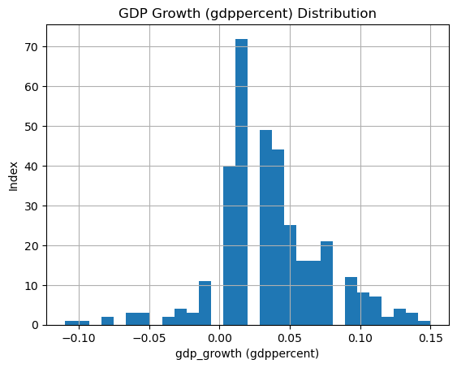

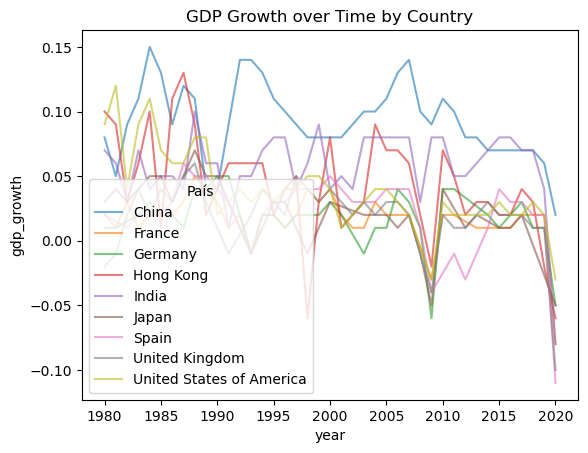

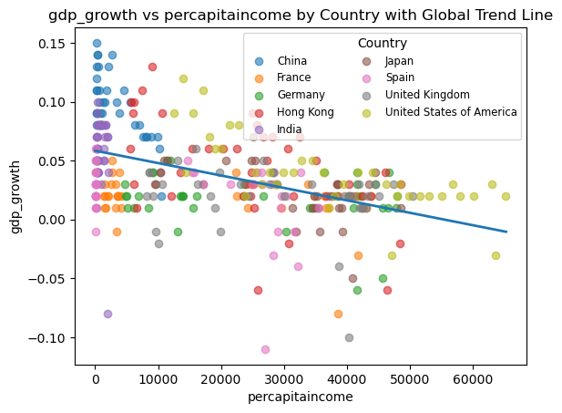

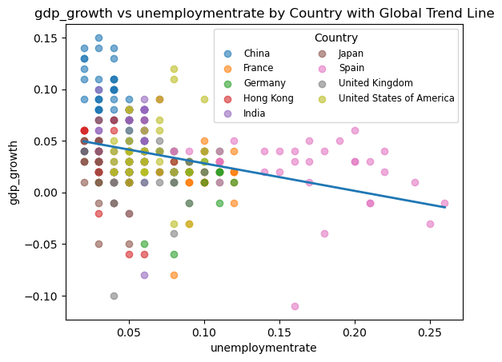

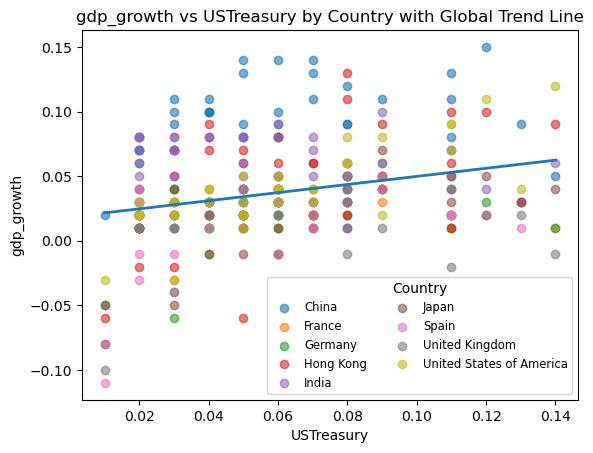

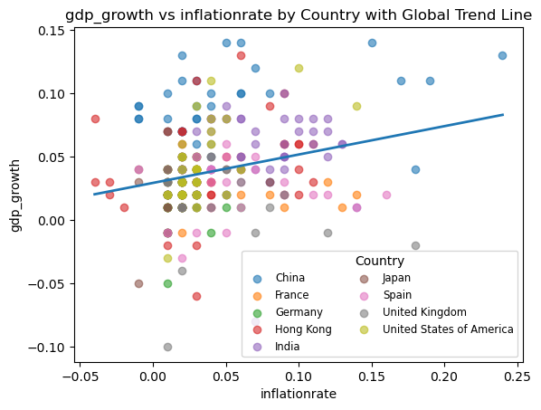

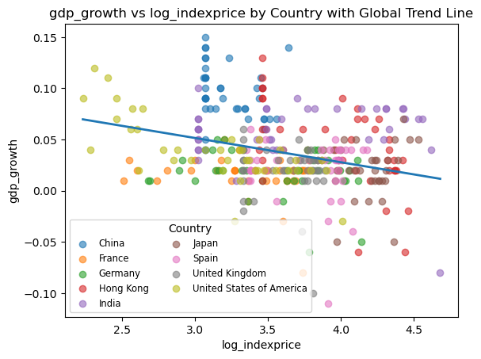

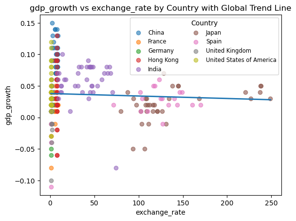

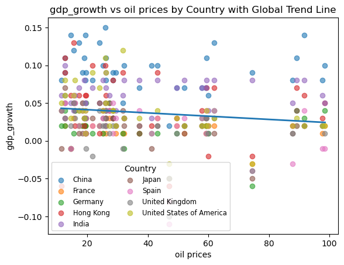

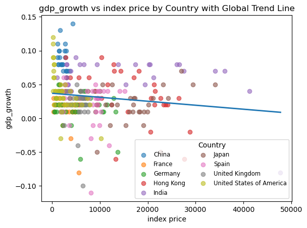

```python
# Historiogram and Scatter Plots of Target vs Predictors

MAX_VARS = 20 #Number of variables to plot, I put 20 because there are much less so all will be considered


plt.figure()
df_model["gdp_growth"].hist(bins=30)
plt.title("GDP Growth (gdppercent) Distribution")
plt.xlabel("gdp_growth (gdppercent)")
plt.ylabel("Index")
plt.show()


# Historical Line Plot of GDP Growth over Time by Country
plt.figure()
for c, g in df_model.groupby(country_col):
    plt.plot(g[year_col], g["gdp_growth"], alpha=0.6, label=str(c))
plt.title("GDP Growth over Time by Country")
plt.xlabel(year_col)
plt.ylabel("gdp_growth")
plt.legend(title="País")
plt.show()


#  Scatter plots for Selected Variables

N_POINTS = 200     # TEndency line resolution

# Colors automatic for countries
countries = df_model[country_col].dropna().unique()
colors = plt.cm.tab10(range(len(countries)))
color_map = dict(zip(countries, colors))

if len(selected_vars) == 0:
    print("There are no selected variables for scatter plots.")
else:
    for col in selected_vars[:MAX_VARS]:

        plt.figure()

        # Scatter plot
        for c in countries:
            df_c = df_model[df_model[country_col] == c]

            x = df_c[col].values
            y = df_c["gdp_growth"].values

            mask = np.isfinite(x) & np.isfinite(y)

            if mask.sum() == 0:
                continue

            plt.scatter(
                x[mask],
                y[mask],
                alpha=0.6,
                color=color_map[c],
                label=str(c)
            )

        # GLobal Trend Line
        x_all = df_model[col].values
        y_all = df_model["gdp_growth"].values
        mask_all = np.isfinite(x_all) & np.isfinite(y_all)

        if mask_all.sum() >= 10:
            m, b = np.polyfit(x_all[mask_all], y_all[mask_all], 1)
            xs = np.linspace(
                np.min(x_all[mask_all]),
                np.max(x_all[mask_all]),
                N_POINTS
            )
            plt.plot(xs, m * xs + b, linewidth=2)

        # Format
        plt.title(f"gdp_growth vs {col} by Country with Global Trend Line")
        plt.xlabel(col)
        plt.ylabel("gdp_growth")
        plt.legend(title="Country", fontsize="small", ncol=2)
        plt.show()
```

INFERENTIAL STATISTICS

We use now inferential statistical tests to support the relationships observed in the correlation and analysis. For each selected predictor, GDP growth is compared between low and high groups defined by the median value of the predictor using Welch’s t-test and the Mann–Whitney test.

Furthermore differences in GDP growth across countries are tested using ANOVA and the Kruskal–Wallis test. Finally, chi-squared tests are applied after discretizing variables into quantiles to assess associations between predictors and GDP growth categories.

```python
# Inferential Statistics
#t-test (Welch) y Mann-Whitney: differences in gdp_growth between groups (split by median)
#ANOVA y Kruskal: differences between countries
#Chi-squared: association after discretization into quantiles


infer_rows = []  # Results list.

for col in selected_vars:  # Just for the selected variables.
    x = df_model[col]  # Predictor.
    y = df_model["gdp_growth"]  # Target.

    med = x.median(skipna=True)  # Calculating median for each predictor.
    g_low = y[x <= med].dropna()  # droping NaNs for low group.
    g_high = y[x > med].dropna()  # droping NaNs for high group.

    if len(g_low) < 10 or len(g_high) < 10:  #If any group coms to be small it skips it
        continue

    t_stat, t_p = stats.ttest_ind(g_low, g_high, equal_var=False)  # Welch t-test.
    try:
        u_stat, u_p = stats.mannwhitneyu(g_low, g_high, alternative="two-sided")  # Mann-Whitney.
    except Exception:
        u_stat, u_p = np.nan, np.nan  # Fallback.

    infer_rows.append({"variable": col, "test": "Welch_t (median)", "stat": float(t_stat), "p_value": float(t_p),
                       "n_low": int(len(g_low)), "n_high": int(len(g_high))})
    infer_rows.append({"variable": col, "test": "Mann_Whitney (median)", "stat": float(u_stat) if np.isfinite(u_stat) else np.nan,
                       "p_value": float(u_p) if np.isfinite(u_p) else np.nan, "n_low": int(len(g_low)), "n_high": int(len(g_high))})

infer_table = pd.DataFrame(infer_rows).sort_values("p_value")  # Creating a table ordered by p-value.

print("T and Mann-Whitney TEsts")
print(infer_table.head(20).to_string(index=False))  # It shows all variables.

# ANOVA / Kruskal by Country
groups = [g["gdp_growth"].dropna().values for _, g in df_model.groupby(country_col)]  # Target by Country

if all(len(g) >= 10 for g in groups) and len(groups) >= 2:  # It verifies sizes.
    f_stat, f_p = stats.f_oneway(*groups)  # ANOVA.
    h_stat, h_p = stats.kruskal(*groups)  # Kruskal.
    print("ANOVA betwen Countries: F =", f_stat, "p =", f_p)
    print("Kruskal Between Countries: H =", h_stat, "p =", h_p)
else:
    print("There are not enough data by country for reliable ANOVA/Kruskal.")

# Chi-squared with discretization into quantiles
def qcut_safe(s, q=4):
    if s.dropna().nunique() < q:  # If there are few unique values
        return pd.Series([np.nan] * len(s), index=s.index)  # It gives NaNs.
    return pd.qcut(s, q=q, duplicates="drop")  # Cutting in to quantiles.

target_cat = qcut_safe(df_model["gdp_growth"], q=4)

chi_rows = []  # Chi Squared results list.

for col in selected_vars:  # Selected variables only.
    x_cat = qcut_safe(df_model[col], q=4)  # Defininf categorical predictor.
    tmp = pd.DataFrame({"x": x_cat, "y": target_cat}).dropna()  # Dropping NaNs.
    if tmp.empty:
        continue
    ct = pd.crosstab(tmp["x"], tmp["y"])  # Contingency table.
    if ct.shape[0] < 2 or ct.shape[1] < 2:  # If there is not enough data
        continue
    chi2, p, dof, expected = stats.chi2_contingency(ct.values)  # Chi-squared test.
    chi_rows.append({"variable": col, "chi2": float(chi2), "dof": int(dof), "p_value": float(p), "shape": str(ct.shape)})

chi_table = pd.DataFrame(chi_rows).sort_values("p_value")  # Ordered by p-value.

print("\Chi-squared REsults")
print(chi_table.head(20).to_string(index=False))
```

```
T and Mann-Whitney TEsts
        variable                  test         stat      p_value  n_low  n_high
 percapitaincome      Welch_t (median)     9.280269 2.197809e-18    175     174
 percapitaincome Mann_Whitney (median) 23014.500000 7.972763e-17    175     174
  log_indexprice      Welch_t (median)     6.629943 1.285007e-10    175     175
unemploymentrate Mann_Whitney (median) 18139.000000 3.576439e-10    203     127
unemploymentrate      Welch_t (median)     6.162295 2.179925e-09    203     127
   exchange_rate Mann_Whitney (median)  9903.000000 1.870398e-08    174     174
  log_indexprice Mann_Whitney (median) 20561.000000 2.281303e-08    175     175
   inflationrate Mann_Whitney (median)  7669.000000 3.349829e-07    184     126
   inflationrate      Welch_t (median)    -5.139143 5.819774e-07    184     126
   exchange_rate      Welch_t (median)    -4.977755 1.017748e-06    174     174
      USTreasury      Welch_t (median)    -4.450791 1.163573e-05    175     175
      USTreasury Mann_Whitney (median) 11291.000000 1.848723e-05    175     175
     index price      Welch_t (median)     4.147979 4.397314e-05    150     149
      oil prices Mann_Whitney (median) 19126.000000 4.875942e-05    176     174
      oil prices      Welch_t (median)     3.939315 9.938168e-05    176     174
     index price Mann_Whitney (median) 13191.500000 6.471565e-03    150     149
ANOVA betwen Countries: F = 30.491871894370284 p = 7.016813372647074e-36
Kruskal Between Countries: H = 154.76578608672176 p = 1.9850113157020115e-29
\Chi-squared REsults
        variable       chi2  dof      p_value  shape
 percapitaincome 101.643714    9 7.315093e-18 (4, 4)
   exchange_rate  52.398385    9 3.800088e-08 (4, 4)
unemploymentrate  47.828724    9 2.749346e-07 (4, 4)
  log_indexprice  40.811325    9 5.413316e-06 (4, 4)
      USTreasury  37.073096    9 2.553944e-05 (4, 4)
   inflationrate  33.858888    9 9.455429e-05 (4, 4)
      oil prices  32.978699    9 1.346973e-04 (4, 4)
     index price  19.065143    9 2.464466e-02 (4, 4)
```

The results show statistically significant differences and associations for most selected variables, providing further evidence that these variables are meaningfully related to GDP growth.

EXPLANATORY OLS REGRESSION

An OLS regression is used to explain GDP growth based on the selected variables and country dummies. The results show several statistically significant predictors and clear differences between countries.

```python
#Explanatory OLS Regression Model

import statsmodels.api as sm  # For OLS regression.


model_cols = [country_col, year_col, "gdp_growth"] + selected_vars  # It defines columns needed.
dfM = df_model[model_cols].copy()  # It creates a DataFrame with the seleected columns.

# We use just numeric selected variables + country dummies + target
for c in selected_vars:
    dfM[c] = pd.to_numeric(dfM[c], errors="coerce")  #It converts it to numeric; if not possible, NaN.

#Dropping rows with missing values in any of the selected variables or target and use just whole rows.
dfM = dfM.dropna(subset=["gdp_growth"] + selected_vars + [country_col])

# Defining Variables and Targt Variables
X = dfM[[country_col] + selected_vars].copy()  # X= predictors (country + selected variables).
y = dfM["gdp_growth"].astype(float)  # y = target variable as float.

# 4) One-hot encoding od the country
X_oh = pd.get_dummies(X, columns=[country_col], drop_first=True)  # It crates dummies for country.

# Converting all X to numeric float (avoids object / Int64 dtype) for modeling
X_oh = X_oh.astype(float)

# Adding constant (intercept) it avoids errors in statsmodels
X_oh = sm.add_constant(X_oh, has_constant="add")

# Adjusting the OLS model
ols = sm.OLS(y, X_oh).fit()

print("Explanatory OLS Regression Model ")
print(ols.summary())
```

```
Explanatory OLS Regression Model
                            OLS Regression Results
==============================================================================
Dep. Variable:             gdp_growth   R-squared:                       0.550
Model:                            OLS   Adj. R-squared:                  0.521
Method:                 Least Squares   F-statistic:                     18.72
Date:                Tue, 30 Dec 2025   Prob (F-statistic):           5.27e-34
Time:                        16:14:25   Log-Likelihood:                 631.43
No. Observations:                 262   AIC:                            -1229.
Df Residuals:                     245   BIC:                            -1168.
Df Model:                          16
Covariance Type:            nonrobust
====================================================================================================
                                       coef    std err          t      P>|t|      [0.025      0.975]
----------------------------------------------------------------------------------------------------
const                               -0.0279      0.038     -0.736      0.462      -0.103       0.047
percapitaincome                  -5.596e-07   2.64e-07     -2.123      0.035   -1.08e-06   -4.05e-08
unemploymentrate                    -0.1794      0.074     -2.430      0.016      -0.325      -0.034
USTreasury                           0.6297      0.127      4.945      0.000       0.379       0.881
inflationrate                       -0.1002      0.071     -1.421      0.156      -0.239       0.039
log_indexprice                       0.0276      0.011      2.614      0.010       0.007       0.048
exchange_rate                    -6.657e-05   6.49e-05     -1.026      0.306      -0.000    6.12e-05
oil prices                           0.0003   7.54e-05      3.559      0.000       0.000       0.000
index price                      -7.784e-07   3.84e-07     -2.027      0.044   -1.53e-06   -2.21e-08
country_France                      -0.0594      0.011     -5.391      0.000      -0.081      -0.038
country_Germany                     -0.0633      0.012     -5.483      0.000      -0.086      -0.041
country_Hong Kong                   -0.0524      0.012     -4.483      0.000      -0.075      -0.029
country_India                       -0.0302      0.010     -3.166      0.002      -0.049      -0.011
country_Japan                       -0.0745      0.017     -4.348      0.000      -0.108      -0.041
country_Spain                       -0.0423      0.014     -2.938      0.004      -0.071      -0.014
country_United Kingdom              -0.0609      0.012     -5.277      0.000      -0.084      -0.038
country_United States of America    -0.0284      0.013     -2.172      0.031      -0.054      -0.003
==============================================================================
Omnibus:                       76.368   Durbin-Watson:                   1.494
Prob(Omnibus):                  0.000   Jarque-Bera (JB):              246.457
Skew:                          -1.235   Prob(JB):                     3.04e-54
Kurtosis:                       7.059   Cond. No.                     2.76e+06
==============================================================================

Notes:
[1] Standard Errors assume that the covariance matrix of the errors is correctly specified.
[2] The condition number is large, 2.76e+06. This might indicate that there are
strong multicollinearity or other numerical problems.
```

This model may be used for interpretation only and does not pretend to target causal inference.

PREDECTVE MODELING SETUP

The predictive analysis is prepared using a temporal train, validation, and test split based on years. The first 75% of the time period is used for training, the next 20% for validation, and the final 5% for testing, ensuring that only past data are used to predict future outcomes.

Numerical and categorical variables are included in the models. Numerical features are imputed and scaled, while the country variable is encoded using one-hot encoding.

```python
#Setup for Predictive Modeling with Temporal Train/Val/Test Split

from sklearn.compose import ColumnTransformer
from sklearn.preprocessing import OneHotEncoder, StandardScaler
from sklearn.pipeline import Pipeline
from sklearn.impute import SimpleImputer
from sklearn.linear_model import LinearRegression, Ridge
from sklearn.tree import DecisionTreeRegressor
from sklearn.metrics import mean_absolute_error, mean_squared_error, r2_score

#Split temporal 75% / 20% / 5% (by YEar)
years_sorted = np.sort(dfM[year_col].dropna().unique())
n_years = len(years_sorted)

cut75 = int(np.floor(0.75 * n_years))
cut95 = int(np.floor(0.95 * n_years))

train_years = years_sorted[:cut75]
val_years   = years_sorted[cut75:cut95]
test_years  = years_sorted[cut95:]

train = dfM[dfM[year_col].isin(train_years)].copy()
val   = dfM[dfM[year_col].isin(val_years)].copy()
test  = dfM[dfM[year_col].isin(test_years)].copy()

num_features = selected_vars
cat_features = [country_col]


# Procesasing Pipelines
numeric_transformer = Pipeline(steps=[
    ("imputer", SimpleImputer(strategy="median")),
    ("scaler", StandardScaler())
])

categorical_transformer = Pipeline(steps=[
    ("imputer", SimpleImputer(strategy="most_frequent")),
    ("onehot", OneHotEncoder(handle_unknown="ignore"))
])

preprocess = ColumnTransformer(
    transformers=[
        ("num", numeric_transformer, num_features),
        ("cat", categorical_transformer, cat_features),
    ],
    remainder="drop"
)

def eval_regression(y_true, y_pred):
    rmse = np.sqrt(mean_squared_error(y_true, y_pred))
    mae  = mean_absolute_error(y_true, y_pred)
    r2   = r2_score(y_true, y_pred)
    return rmse, mae, r2

print("Temporal Split")
print("Train years:", int(train_years.min()), "-", int(train_years.max()))
print("Val years:", int(val_years.min()), "-", int(val_years.max()))
print("Test years:", int(test_years.min()), "-", int(test_years.max()))
```

```
Temporal Split
Train years: 1980 - 2009
Val years: 2010 - 2017
Test years: 2018 - 2020
```

MODEL TRAINING AND VALIDATION

Three predictive models are trained using the training period and evaluated on the validation set: linear regression, ridge regression, and a decision tree model. Model performance is compared using RMSE, MAE, and R squared.

```
Validation 20%
           model     RMSE      MAE        R2
           Ridge 0.017459 0.014413  0.633427
LinearRegression 0.018906 0.015650  0.570145
    DecisionTree 0.051892 0.045665 -2.238323
Validation Model Ridge
```

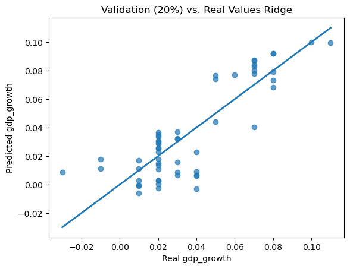

```python
# First training and validation (75% / 20%)

models = {
    "LinearRegression": LinearRegression(),
    "Ridge": Ridge(alpha=1.0, random_state=0),
    "DecisionTree": DecisionTreeRegressor(max_depth=4, random_state=0)
}

results = []
pipes = {}

X_train = train[cat_features + num_features]
y_train = train["gdp_growth"]

X_val = val[cat_features + num_features]
y_val = val["gdp_growth"]

for name, est in models.items():
    pipe = Pipeline(steps=[("preprocess", preprocess), ("model", est)])
    pipe.fit(X_train, y_train)
    y_val_pred = pipe.predict(X_val)

    rmse, mae, r2 = eval_regression(y_val, y_val_pred)
    results.append({"model": name, "RMSE": rmse, "MAE": mae, "R2": r2})
    pipes[name] = pipe

results_df = pd.DataFrame(results).sort_values("RMSE")
print("Validation 20%")
print(results_df.to_string(index=False))

best_model_name = results_df.iloc[0]["model"]
best_pipe_75 = pipes[best_model_name]
best_val_pred = best_pipe_75.predict(X_val)

print(f"Validation Model {best_model_name}")

#Visualization of Real vs Predicted for the Best Model in Validation Set
plt.figure()
plt.scatter(y_val, best_val_pred, alpha=0.7)
minv = float(np.nanmin(y_val))
maxv = float(np.nanmax(y_val))
plt.plot([minv, maxv], [minv, maxv], linewidth=2)
plt.title(f"Validation (20%) vs. Real Values {best_model_name}")
plt.xlabel("Real gdp_growth")
plt.ylabel("Predicted gdp_growth")
plt.show()
```

Ridge regression shows the best performance on the validation data, with the lowest prediction error and the highest R sqared value. The scatter plot of predicted versus actual GDP growth for the validation set shows a clear positive relationship, although some dispersion remains around the diagonal.

FINAL TRAINING AND TEST EVALUATION

The best-performing model from the validation stage (ridge regression) is retrained using 95% of the available data and evaluated on the final 5%, which corresponds to the most recent years in the dataset.

```
TEST (Last 5%) — Ridge etrained with the 95% od the Data
RMSE: 0.049728896926061715
MAE : 0.030129389090127974
R2  : -0.3574517881029944
```

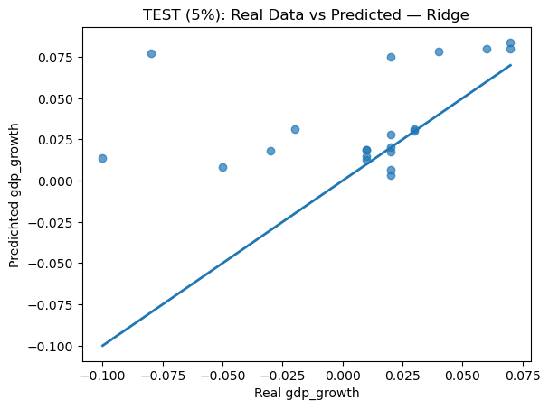

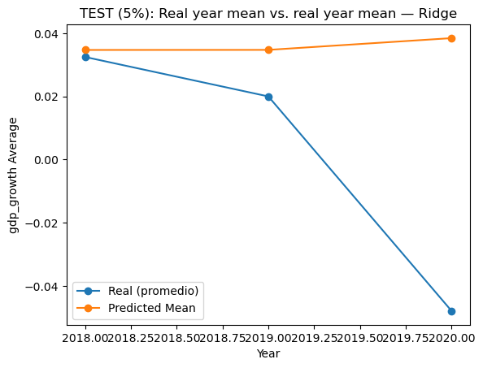

```python
# Re Training (95%) + Test final (5%)


#It takes the best model from validation and retrains it with 95% of the data, then evaluates on the last 5%.
best_est = models[best_model_name]

best_pipe_95 = Pipeline(steps=[("preprocess", preprocess), ("model", best_est)])

train_val = pd.concat([train, val], axis=0)
X_train_val = train_val[cat_features + num_features]
y_train_val = train_val["gdp_growth"]

X_test = test[cat_features + num_features]
y_test = test["gdp_growth"]

best_pipe_95.fit(X_train_val, y_train_val)
y_test_pred = best_pipe_95.predict(X_test)

rmse_t, mae_t, r2_t = eval_regression(y_test, y_test_pred)

print(f"TEST (Last 5%) — {best_model_name} etrained with the 95% od the Data")
print("RMSE:", rmse_t)
print("MAE :", mae_t)
print("R2  :", r2_t)

# Visualization for Test Set
plt.figure()
plt.scatter(y_test, y_test_pred, alpha=0.7)
minv = float(np.nanmin(y_test))
maxv = float(np.nanmax(y_test))
plt.plot([minv, maxv], [minv, maxv], linewidth=2)
plt.title(f"TEST (5%): Real Data vs Predicted — {best_model_name}")
plt.xlabel("Real gdp_growth")
plt.ylabel("Predichted gdp_growth")
plt.show()

#Visualization 2: Annual Average Real vs Predicted in Test Set
test_out = test[[country_col, year_col, "gdp_growth"]].copy()
test_out["pred"] = y_test_pred

yearly = test_out.groupby(year_col)[["gdp_growth", "pred"]].mean().reset_index()

plt.figure()
plt.plot(yearly[year_col], yearly["gdp_growth"], marker="o", label="Real (promedio)")
plt.plot(yearly[year_col], yearly["pred"], marker="o", label="Predicted Mean")
plt.title(f"TEST (5%): Real year mean vs. real year mean — {best_model_name}")
plt.xlabel("Year")
plt.ylabel("gdp_growth Average")
plt.legend()
plt.show()
```

While the model shows reasonable behavior during validation, its performance on the final test set is weak, as reflected by higher prediction errors and a negative R aquared. The scatter plot and the comparison of yearly averages show that the model fails to capture the sharp changes observed in the last period.

This result is expected, since the model is trained only on historical macroeconomic patterns and does not account for the structural economical crack caused by the COVID-19 pandemic in 2019–2020. These years represent an external event that is not present in the training data and therefore cannot be anticipated by the model.

CONCLUSION

This project shows how data science can be a powerful tool to understand economic dynamics at local and global cases, using historical data collected over many years. By applying statistical screening, correlation analysis, and predictive models, it is possible to identify which economic variables are meaningfully related to GDP growth and how these relationships differ across countries.

In any case, the analysis also shows an important limitation of data-driven models. Even when large datasets and rigorous statistical methods are used, economic behavior is not fully predictable. Historical, political, social, and natural events can cause suddenly structural changes that are impossible to anticipate based only on data.

Other major events, like the war between Russia and Ukraine, have also reshaped global economic relations and strongly affected European economies. Similarly, recent political decisions and policy changes under the Trump administration introduced unexpected economic effects whose short- and long-term impacts remain uncertain. These types of events fall outside the scope of purely statistical modeling.

For this reason, data science should not be used in isolation. Instead, it should remain in constant dialogue with other disciplines such as economics, political science, sociology, and public health. Combining statistical evidence with contextual and domain knowledge is essential for making informed and responsible decisions in complex economic environments.